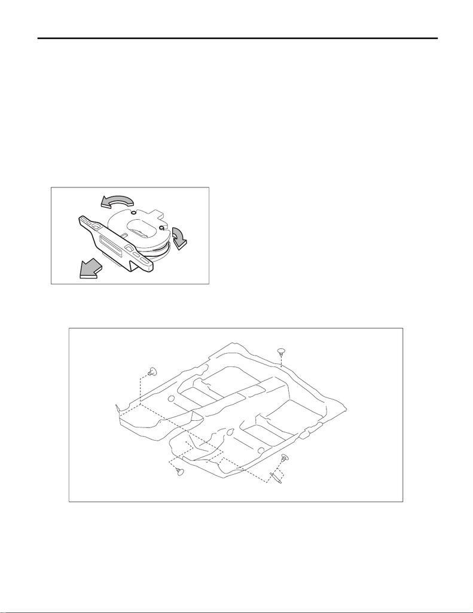

EI-105

Floor Mat

EXTERIOR/INTERIOR TRIM

31.Floor Mat

A: REMOVAL

1) Disconnect the ground cable from battery. <Ref. to NT-5, BATTERY, NOTE, Note.>

NOTE:

• For models other than STI model, disconnect the ground terminal from battery sensor.

• On CVT models, shift the select lever into “D” before disconnecting the battery ground cable.

2) Remove the front seat assembly. <Ref. to SE-9, REMOVAL, Front Seat.>

3) Remove the rear seat cushion assembly. <Ref. to SE-29, REMOVAL, Rear Seat.>

5) Remove the lower inner trim on the RH and LH sides. <Ref. to EI-81, REMOVAL, Lower Inner Trim.>

6) Remove the pull handle cover. <Ref. to SL-59, FUEL FLAP, REMOVAL, Remote Openers.>

7) Remove the knobs of the hook - seat cushion rear.

8) Take out the floor mat from the vehicle.

(1) Remove the clips from the floor mat.

(2) Remove the mat hook on both sides.

(3) Take out the floor mat after folding down.

EI-03524

EI-03518

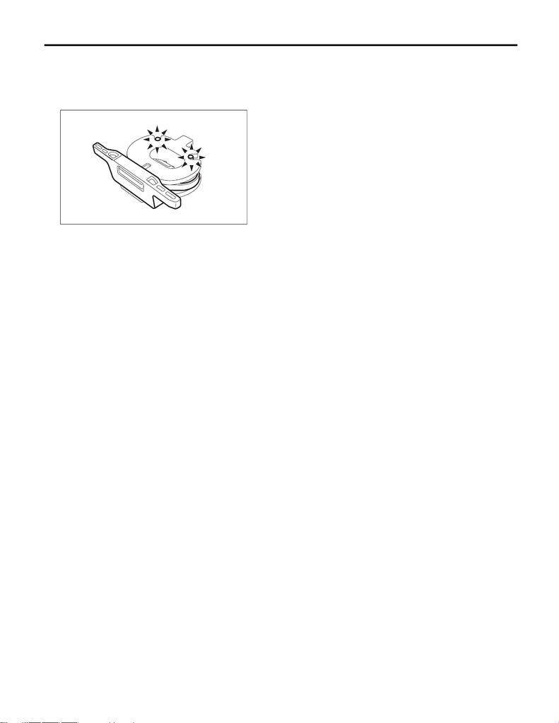

Floor Mat

EXTERIOR/INTERIOR TRIM

B: INSTALLATION

1) Bring the floor mat into the vehicle, and secure with the clips.

CAUTION:

Make sure that the knobs of the hook - seat cushion rear are securely installed.

2) Install the pull handle cover.

3) Install the lower inner trim.

4) Install the console box assembly, the cover - shift lever and the panel center LWR.

5) Install the rear seat cushion assembly.

6) Install the front seat.

Tightening torque:

53 N·m (5.4 kgf-m, 39.1 ft-lb)

7) Connect the battery ground terminal. <Ref. to NT-5, BATTERY, NOTE, Note.>

NOTE:

For models other than STI model, connect the ground terminal to battery sensor.

EI-03525

[figure not shown]

EXTERIOR BODY PANELS

EB

Page

3. Front Fender ............................................................................................19

4. Front Door ................................................................................................24

5. Front Sealing Cover .................................................................................32

6. Rear Door .................................................................................................34

7. Rear Sealing Cover ..................................................................................41

8. Door Sash Tape .......................................................................................42

9. Trunk Lid ..................................................................................................51

10. Weather Strip ...........................................................................................58